# latihan 5

Tugas: Menggunakan data yang sudah dibagi di pertemuan 2 (masing-masing minimal 100 data), lakukan pengecekan ketidakstasioneran dalam rataan dan ragam. Jika tidak terpenuhi stasioneritasnya, lakukan penanganan yang sesuai

# Library

```r
library(readxl)
library(ggplot2)
library(tsibble)
library(tseries)
library(MASS)
library(forecast)
```

# Data

```r
dt <- read_xlsx("~/Kuliah/Semester 5/MPDW/MPDW Separated.xlsx")
dt.ts<-ts(dt)
```

## Eksplorasi Data

### Plot Data Penuh

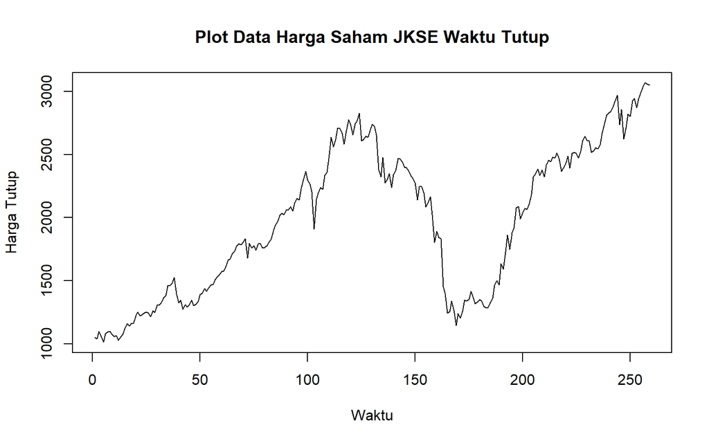

```r
plot.ts(dt.ts[,"Close"], lty=1, xlab="Waktu", ylab="Harga Tutup",
        main="Plot Data Harga Saham JKSE Waktu Tutup")
```

Berdasarkan plot data deret waktu, terlihat bahwa data cenderung memiliki trend fluktuatif dari naik ke turun dan kembali naik. Berdasarkan pola data, pembagian data latih dan data uji ditetapkan dengan proporsi 89%:11%.

### Plot Data Latih

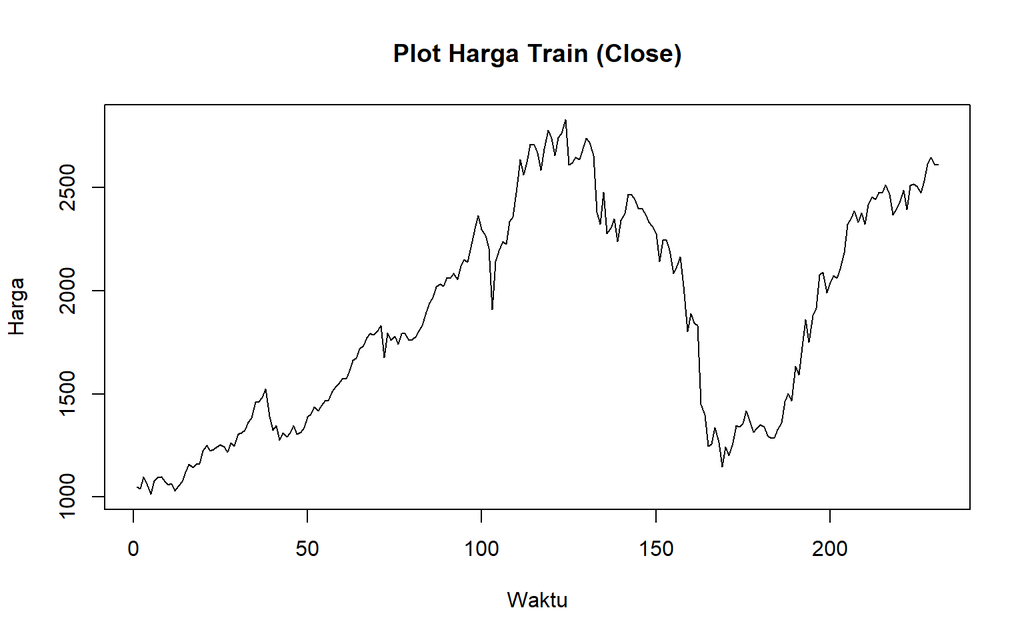

```r
# ambil hanya kolom harga (misalnya "Close")
dtclose <- dt.ts[,"Close"]

# bagi train set sesuai indeks
dttrain <- dtclose[1:231]
train.ts <- ts(dttrain)

# plot ulang
plot.ts(train.ts, lty=1, xlab="Waktu", ylab="Harga",
        main="Plot Harga Train (Close)")
```

Berdasarkan plot data deret waktu pada data latih, terlihat bahwa data cenderung memiliki trend fluktuatif dan tidak bergerak pada nilai tengah tertentu. Hal ini mengindikasikan bahwa data tidak stasioner dalam rataan.

### Plot Data Uji

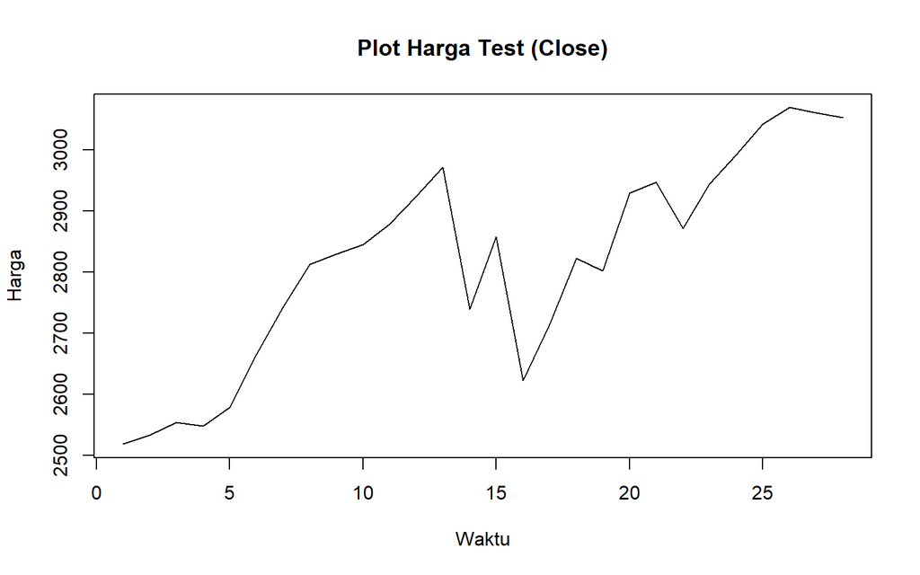

```r
dttest <- dtclose[232:259]
test.ts <- ts(dttest)
plot.ts(test.ts, lty=1, xlab="Waktu", ylab="Harga",
        main="Plot Harga Test (Close)")
```

# Uji Stasioneritas Data

## Plot ACF

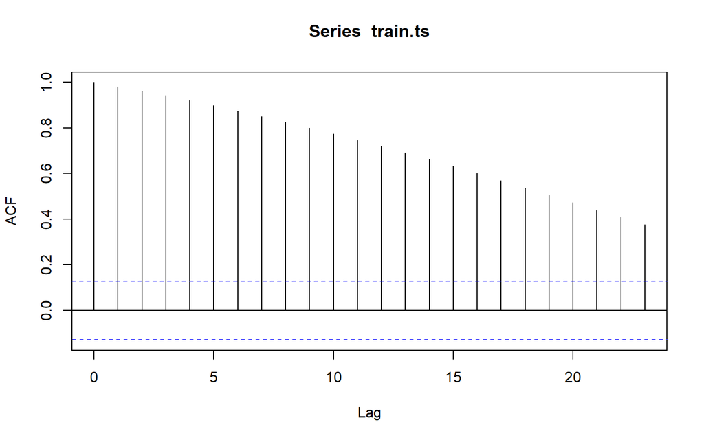

```r
acf(train.ts)
```

Berdasarkan plot ACF, terlihat bahwa plot ACF pada data tersebut menurun secara perlahan (*tails off slowly*) yang menandakan data tidak stasioner dalam rataan

## Uji ADF

$H_0$ : Data tidak stasioner dalam rataan $H_1$ : Data stasioner dalam rataan

```r
tseries::adf.test(train.ts)
```

```
##
##  Augmented Dickey-Fuller Test
##
## data:  train.ts
## Dickey-Fuller = -1.7782, Lag order = 6, p-value = 0.6691
## alternative hypothesis: stationary
```

## Plot Box-Cox

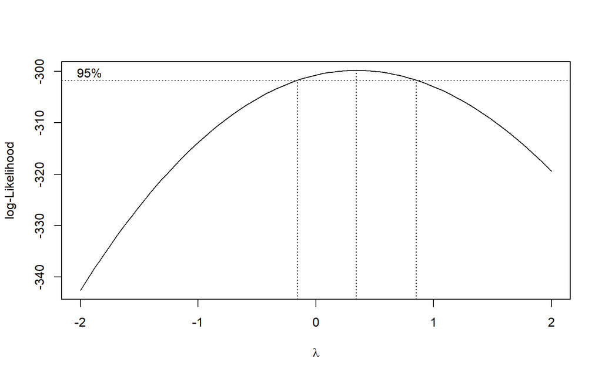

```r
index <- seq(1:231)
bc = boxcox(train.ts~index, lambda = seq(-2,2,by=1))
```

```r
lambda <- bc$x[which.max(bc$y)]
lambda
```

```
## [1] 0.3434343
```

```r
# Selang kepercayaan 95% untuk lambda
ci_lambda <- bc$x[bc$y > max(bc$y) - 0.5 * qchisq(0.95, 1)]

# Batas bawah dan batas atas
ci_lower <- min(ci_lambda)
ci_upper <- max(ci_lambda)

c(Batas_Bawah = ci_lower, Batas_Atas = ci_upper)
```

```
## Batas_Bawah  Batas_Atas
##  -0.1414141   0.8282828
```

Gambar di atas menunjukkan nilai λ optimum (rounded value) sebesar 0.343434 dan selang kepercayaan 95% nilai memiliki batas bawah -0.1414141 dan batas atas 0.8282828. Selang tersebut tidak memuat nilai satu sehingga dapat dikatakan bahwa data tidak stasioner dalam ragam.

# Penanganan Ketidakstasioneran Data

## Transformasi Box-Cox

```r
train.ts <- (train.ts^lambda-1)/lambda
```

## Differencing 1

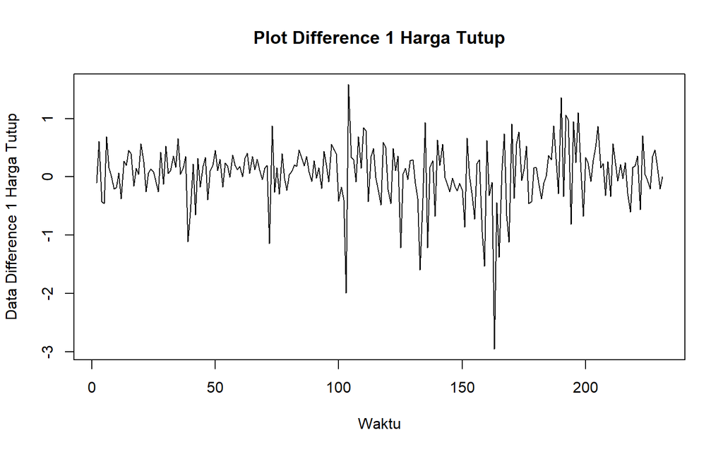

```r
train.diff <- diff(train.ts,differences = 1)
plot.ts(train.diff, lty=1, xlab="Waktu", ylab="Data Difference 1 Harga Tutup", main="Plot Difference 1 Harga Tutup")
```

### Plot ACF

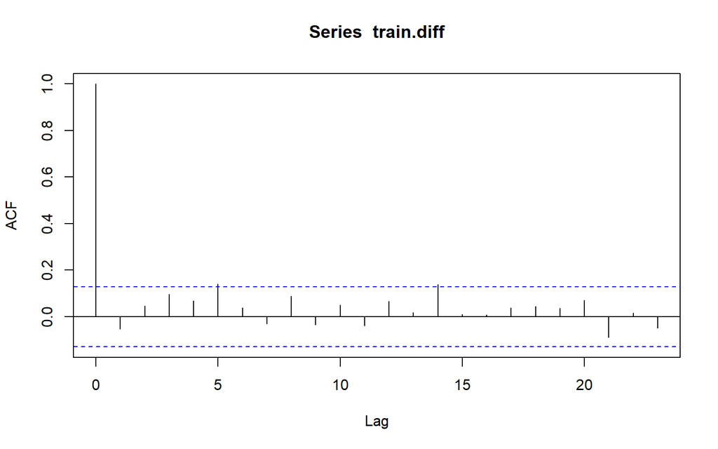

```r
acf(train.diff)
```

Berdasarkan plot tersebut, terlihat bahwa plot ACF sudah tails off secara normal (tidak slowly). Hal ini menandakan data sudah stasioner dalam rataan dan ketidakstasioneran data telah berhasil tertangani.

### Uji ADF

```r
tseries::adf.test(train.diff)
```

```
##
##  Augmented Dickey-Fuller Test
##
## data:  train.diff
## Dickey-Fuller = -4.5264, Lag order = 6, p-value = 0.01
## alternative hypothesis: stationary
```

Berdasarkan uji ADF tersebut, didapat p-value sebesar 0.01 yang lebih kecil dari taraf nyata 5% sehingga tolak dan menandakan bahwa data sudah stasioner dalam rataan. Hal ini sesuai dengan hasil eksplorasi menggunakan plot time series dan plot ACF.

### Plot Box-Cox

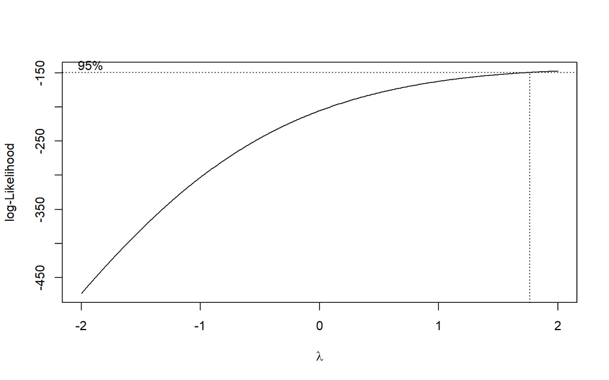

```r
train_shift <- train.diff - min (train.diff) + 1
index <- seq_along(train_shift)
bc = boxcox(train_shift~index, lambda = seq(-2,2,by=0.01))
```

```r
#Nilai Rounded Lambda
lambda <- bc$x[which.max(bc$y)]
lambda
```

```
## [1] 2
```

```r
#SK
bc$x[bc$y > max(bc$y) - 1/2 * qchisq(.95,1)]
```

```
##  [1] 1.77 1.78 1.79 1.80 1.81 1.82 1.83 1.84 1.85 1.86 1.87 1.88 1.89 1.90 1.91
## [16] 1.92 1.93 1.94 1.95 1.96 1.97 1.98 1.99 2.00
```

## Differencing 2

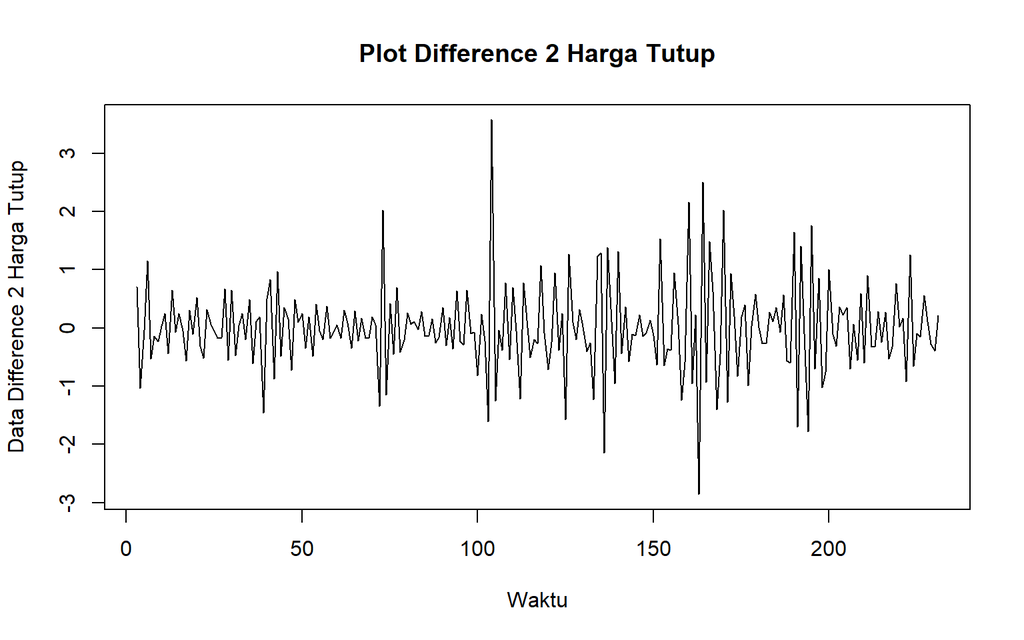

```r
train.diff2 <- diff(train.diff,differences = 1)
plot.ts(train.diff2, lty=1, xlab="Waktu", ylab="Data Difference 2 Harga Tutup", main="Plot Difference 2 Harga Tutup")
```

Berdasarkan plot data deret waktu, terlihat bahwa data sudah stasioner dalam rataan ditandai dengan data bergerak pada nilai tengah tertentu (tidak terdapat trend ataupun musiman pada data)

### Plot ACF

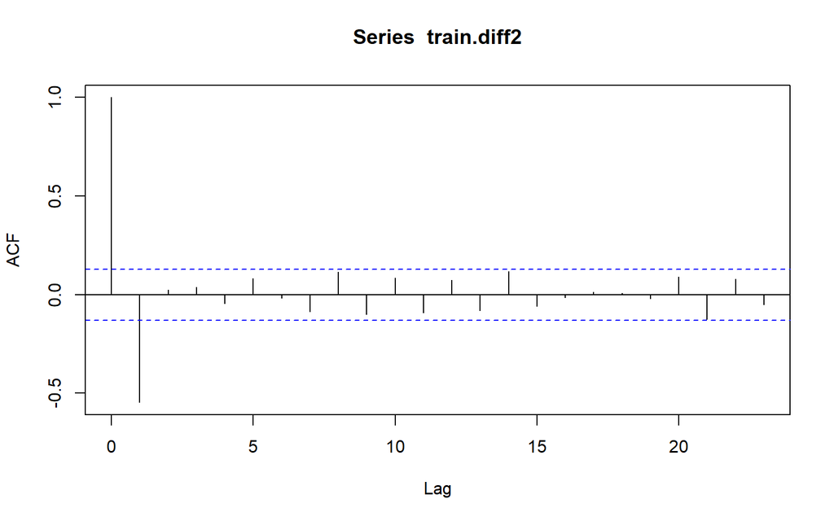

```r
acf(train.diff2)
```

Berdasarkan plot tersebut, terlihat bahwa plot ACF sudah tails off secara normal (tidak slowly). Hal ini menandakan data sudah stasioner dalam rataan dan ketidakstasioneran data telah berhasil tertangani.

### Uji ADF

```r
tseries::adf.test(train.diff2)
```

```
##
##  Augmented Dickey-Fuller Test
##
## data:  train.diff2
## Dickey-Fuller = -9.028, Lag order = 6, p-value = 0.01
## alternative hypothesis: stationary
```

Berdasarkan uji ADF tersebut, didapat p-value sebesar 0.01 yang lebih kecil dari taraf nyata 5% sehingga tolak dan menandakan bahwa data sudah stasioner dalam rataan. Hal ini sesuai dengan hasil eksplorasi menggunakan plot time series dan plot ACF.

### Plot Box-Cox

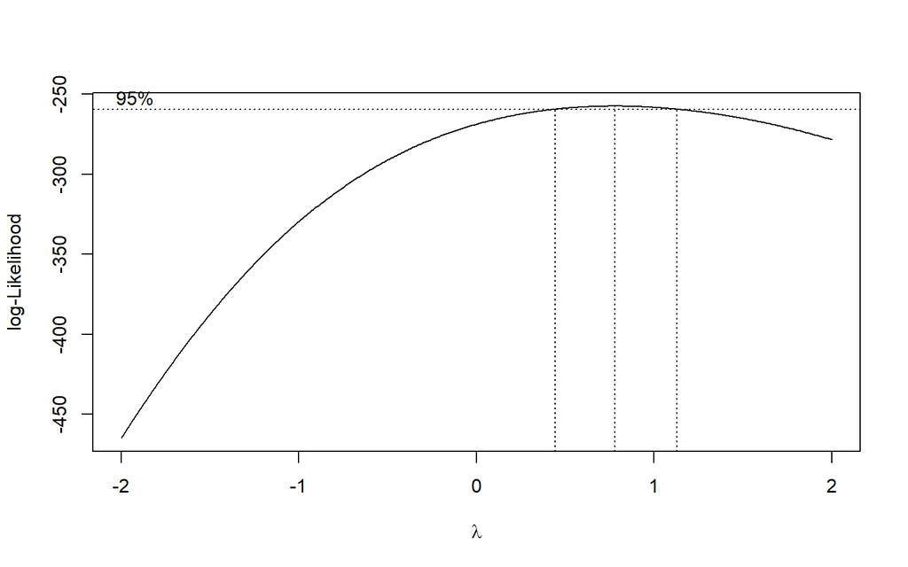

```r
train_shift2 <- train.diff2 - min (train.diff2) + 1
index <- seq_along(train_shift2)
bc2 = boxcox(train_shift2~index, lambda = seq(-2,2,by=0.01))
```

```r
#Nilai Rounded Lambda
lambda2 <- bc2$x[which.max(bc2$y)]
lambda2
```

```
## [1] 0.78
```

```r
#SK
bc2$x[bc2$y > max(bc2$y) - 1/2 * qchisq(.95,1)]
```

```
##  [1] 0.45 0.46 0.47 0.48 0.49 0.50 0.51 0.52 0.53 0.54 0.55 0.56 0.57 0.58 0.59
## [16] 0.60 0.61 0.62 0.63 0.64 0.65 0.66 0.67 0.68 0.69 0.70 0.71 0.72 0.73 0.74
## [31] 0.75 0.76 0.77 0.78 0.79 0.80 0.81 0.82 0.83 0.84 0.85 0.86 0.87 0.88 0.89
## [46] 0.90 0.91 0.92 0.93 0.94 0.95 0.96 0.97 0.98 0.99 1.00 1.01 1.02 1.03 1.04
## [61] 1.05 1.06 1.07 1.08 1.09 1.10 1.11 1.12 1.13
```

Gambar di atas menunjukkan nilai λ optimum (rounded value) sebesar 0.78 dan selang kepercayaan 95% nilai memiliki batas bawah 0.45 dan batas atas 1.13. Selang tersebut memuat nilai satu sehingga dapat dikatakan bahwa data sudah stasioner dalam ragam.

Kesimpulan: Dari penanganan kestasioneritasan didapatkan bahwa data telah berhasil stasioner dalam rataan maupun dalam ragam dan selanjutnya dapat dilakukan identifikasi model tentatif